# Tutorial and assignment week 11 - Binomial models

Torbjørn Ergon and Tom Andersen

2022-03-15

This tutorial is a fairly comprehensive (but not in-depth) overview of binomial models commonly used in Biology. Sections (or parts of sections) marked with a “*” are not part of the syllabus but are included to give you an overview of related topics that you likely have to read up on later in your career.

## Key terms and concepts covered in this tutorial

- Binomial models
- Maximum likelihood estimation
- Generalized linear models (glm)
- Contingency tables, odds and odds ratios
- Binomial glm with logit link
- Hazard rate and survival
- Binomial glm with complementary log-log link

## Prerequisites

We assume that you have a general understanding of terms and concepts from the previous tutorials and lectures, and in addition we assume you are familiar with the following (from STK1000 or similar):

- Binomial distribution
- Exponentials and logarithms (see the extra [Tutorial on Exponents and Logarithms](https://uio.instructure.com/files/635816/download?download_frd=1) at the end of the Week 1 module)

## Binomial models

In binomial models, we aim to predict probabilities. Instead of having a response variable that represents e.g. length, volume, mass, speed, light intensity, etc., the response variable is now a count of “successes” in a number of “trials”. For example, we may want to investigate how the prevalence of a particular disease or another condition changes in a population over time or among locations. In a specific sample of $n$ individuals, we may find that $y$ individuals have the particular condition ($y$ is called “number of successes” even when we count something that is bad for the individuals (or other study units)). If the individuals have been sampled independently of each other, $y$ can be considered as having been drawn at random from a binomial distribution. One typically writes this as

$$y \sim \text{Binomial}(n,p)$$

You can read the “$\sim$” as “drawn from”. This means that $P(Y=y) = \binom{n}{y} p^{y} (1-p)^{n-y}$, where $Y$ is the the stochastic variable representing the number of successes you may get in $n$ trials (the notation $P(Y=y)$ means “the probability that $Y$ takes the value $y$”). The parameter $p$ is the probability of success (e.g. testing positive for the disease) for a single study unit (e.g., individual) and study units are assumed to be independent. In the expression for the binomial distribution above, $\binom{n}{y} = n!/(y!(n-y)!)$. This is the “binomial coefficient” which is the number of different ways of distributing $y$ successes in a sequence of $n$ trials. In R, we can compute this with the function `choose(n,y)`.

Binomial models are different from regular linear models in that the response variable is not on the same scale as what we are trying to predict. What we are trying to predict is the parameter $p$ in the underlying binomial distribution. The probability $p$ is always the success probability of an *individual study unit* in the sample. Unlike e.g. the length of a body part, we cannot measure an individual’s probability of e.g. getting a disease or dying (it either does or it doesn’t). We say that such probabilities are “latent characteristics” which can only be predicted based on statistical modelling of data from many individuals (but the characteristics are nevertheless characteristics of the *individuals*).

**FOR A DEEPER UNDERSTANDING (may be skipped):**

### *Maximum likelihood estimation of $p$

Assume that we have a sample of 10 individuals and the true prevalence of a disease is 35%. In many such samples we should then on average get 3.5 individuals with the disease per sample. However, in a single sample we may get, say, 3 or 6 positive individuals. We may even get 10, but that is much less likely than getting 3 or 4 (we will certainly not get 3.5). We can use the expression for the binomial distribution above to calculate the probability of getting any number between 0 and 10 positive individuals in the sample. In R we can do this with the `dbinom()` function. Let’s do that and make a plot:

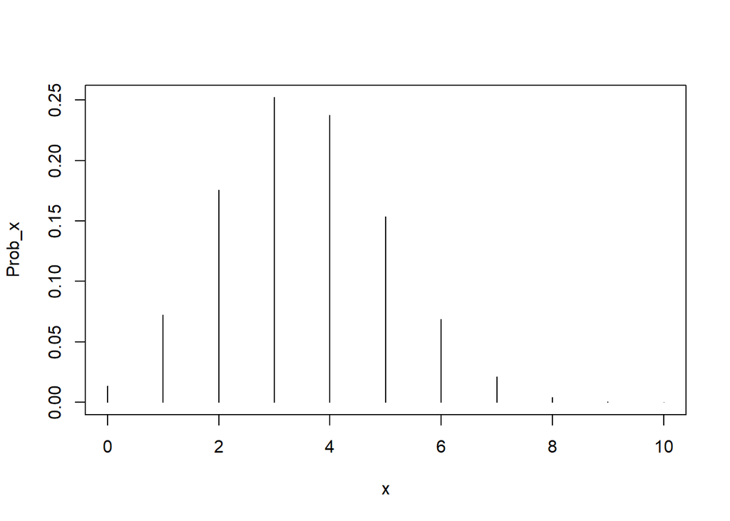

```r
x = 0:10
Prob_x = dbinom(x, 10, 0.35)
plot(x, Prob_x, type="h")
```

If we had used the `rbinom()` function to sample a large number of values from this distribution this is the expected frequency of each value from 0 to 10 (you can confirm that these values sum to 1 with `sum(Prob_x)`).

Let’s say we get $y=5$ positive individuals in our sample. Our best estimate of $p$ is then obviously $5/10 = 0.5$. We will now obtain this estimate through the maximum likelihood estimation method to see how it works. This method can be applied generally to a wide range of estimation problems, also when we cannot derive a mathematical expression for the estimate and have to use numerical computation.

According to the maximum likelihood principle we should pick the value of $p$ that maximizes the likelihood of getting the observed data. This value is the *maximum likelihood estimate* of $p$. To find this value, we can first plot the probability $Pr(Y=5)$ as a function of $p$:

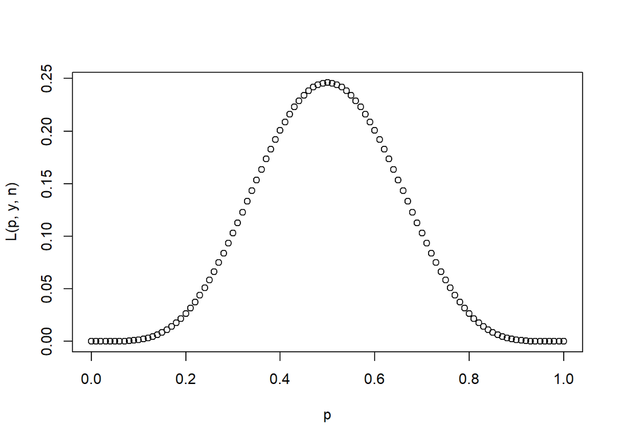

```r
y = 5 # observed data
n = 10
L = function(p, y, n) choose(n,y) * p^y * (1-p)^(n-y) # see binomial probability expression above
p = seq(0, 1, by = 0.01) # values of p ranging from 0 to 1
plot(p, L(p, y, n)) # include argument type = "l" to get a line instead
```

(Instead of the `L` function we define here, we could have used the `dbinom` function we used above)

Note that this nice bell-shaped curve is not a probability distribution (the area under the curve is not 1). It is simply the probability of getting the data we have got for each hypothetical (candidate) value of $p$ plotted on the x-axis [Since the outcome $y$ is here a whole number, we can use the word “probability” instead of “likelihood”]. One generally writes this function as $L(\Theta; \text{Data})$ which can be read as “the likelihood of the parameters ($\Theta$) given the data”. Note that the expression for $L(p; y, n)$ is the same as the expression for $Pr(Y=y)$, but instead of viewing the expression as a function of $y$ with known $p$, we view it as a function of the parameter $p$ with known $y$.

In this example we can find the maximum likelihood estimate of $p$ by picking out the value of the `p` vector where `L(p, y, n)` is at maximum:

```r
likelihood = L(p, y, n)
p[likelihood == max(likelihood)]
```

```
## [1] 0.5
```

The plot above indicates that there is quite a bit of uncertainty in this estimate; if the true value of the parameter is 0.4 or 0.6, then we are almost as likely to get the observed data. Naturally, if we had more data, we would have got a narrower peak of the likelihood curve, indicating a more certain estimate.

Let’s see what the likelihood looks like if we had observed 50 positive individuals in a sample of 100. Below, we add this as a blue line in the plot:

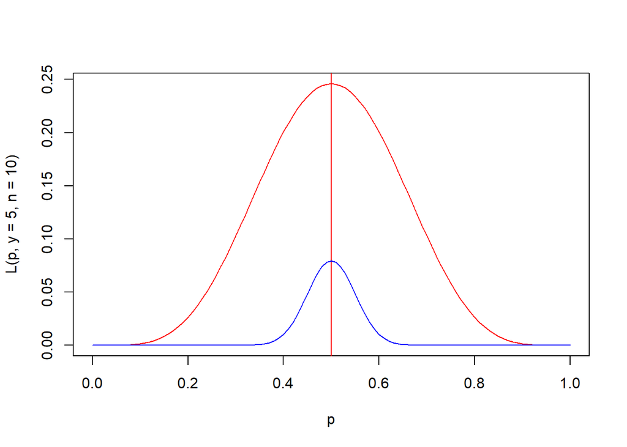

```r
plot(p, L(p, y=5, n=10), type="l", col="red")
abline(v=y/n, col="red")
lines(p, L(p, y=50, n=100), col="blue")
```

As expected, the peak of the blue curve is a lot narrower, indicating more certainty of the estimate. The fact that the likelihood values are much smaller when $n=100$ just reflects that it is much less likely to get exactly $y=50$ positives in a sample of 100 than it is to get $y=5$ in a sample of 10. All we care about here is the location of the peak (at $p=0.5$) and the width of the peak. We will later show that we can create a confidence interval for $\hat{p}$ based on the shape of the likelihood curve (or generally a multi-dimensional surface when we have more then one parameter in the model).

For several reasons one usually maximizes the log of the likelihood instead of the likelihood itself (what maximizes the log of the likelihood also maximizes the likelihood itself). We can also ignore constant terms (terms that do not include the parameter) because these do not affect the location of the peak. Hence, since $\log \left( p^y (1-p)^{(n-y)} \right) = y\log(p) + (n-y)\log(1-p)$ we maximize the log-likelihood function $\ell (p; y,n) = y\log(p) + (n-y)\log(1-p)$. Let us plot this function as well when $y=5$ and $n=10$:

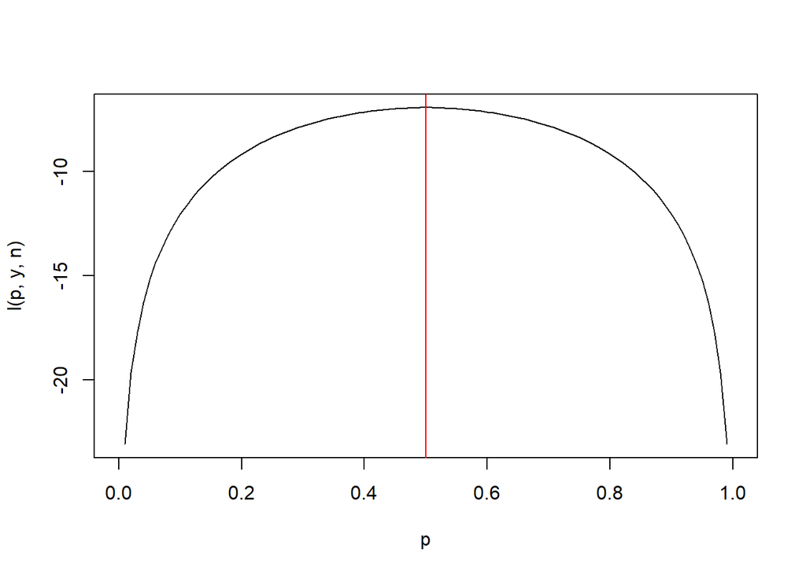

```r
l = function(p, y=5, n=10) y*log(p) + (n-y)*log(1-p)
plot(p, l(p, y, n), type="l")
abline(v=y/n, col="red")
```

In this case the likelihood function is so simple that you could have found the peak analytically by setting the first derivative of the function to zero and solving for $p$ (i.e., solve $\frac{\partial \ell (p)}{\partial p} = 0$; we leave this for you to show on your own). However, in complex likelihood functions with many parameters one needs to find the peak on a multidimensional surface, and it is often necessary to do this maximization by numerical computation (cannot be solved analytically). We will return to that later.

## Modelling $p$

We are often interested in trying to model the variation in the success probability ($p$) among individuals. For example, we may want to study how the probability of having a condition is associated with age or some environmental factor. Or perhaps we want to build a model to predict the risk of developing a heart disease such that people at risk can be warned or examined.

Let’s say that the overall probability of being positive for a chronic medical disorder (e.g. diabetes) is 0.05. I.e., if we pick a random individual from the population, the probability that this individual has the condition is 0.05. We can call this the unconditional probability, because this is our prediction if we know nothing about the individual. If, however, we know the age of the individual, we may be able to give a better prediction (probability conditional on age). For example, a lower probability if the individual is young or a higher probability if the individual is old.

So, how can we make a model for an individual $i$’s probability of success, $p_i$? Just making $p_i$ a linear function of age would be a strange model as it is hard to come up with any biological theory for why we should expect a straight line. Besides such a model could predict probabilities outside the 0 to 1 range, which is nonsense. It is customary to transform the $p$-parameter to a log-odds scale before applying a linear model, such that $\log \left( \frac{p_i}{1-p_i} \right) = \mathbf{x}_i \mathbf{\beta}$ – this is called a “logit” link function, which we will introduce below.

### Odds, odds ratios and the logit link

Odds is simply an alternate way of expressing probability, as in when we informally say “the chance is one in a million for that to happen” instead of saying “the probability is 0.000001”. Formally, the odds of an event with probability $p$ is defined as $p / (1 - p)$, or the ratio of the probability of success to the probability of non-success. For example, if a betting agency states that the odds of a specific horse winning a race is $1/3$ (“one to three”), the probability that this horse will win is considered to be $p = 1/4 = 0.25$ (the probability of not winning is three times as high as the probability of winning; odds = $0.25/(1-0.25) = 1/3$). Note that the odds is just a sample transformation of the probability.

A consequence of this transformation is that we have changed the domain from the unit interval (0 to 1) to the positive part on the real line: the odds is close to zero when $p$ is low but grows towards $+\infty$ as $p$ approaches 1. If we log-transform the odds of a probability ($\log(p / (1-p)) = \text{logit}(p)$) we expand the domain to the whole real line. This means that $\text{logit}(p)$ approaches $-\infty$ when $p$ becomes very small, is zero when $p = 0.5$ (which is equivalent to $p / (1 - p) = 1$) and goes toward $+\infty$ as $p$ approaches 1. This also means that $\text{logit}(p)$ is better suited to be modelled by a weighted sum of the predictor variables, since these values can in principle take any real-numbered value (i.e., from $-\infty$ to $+\infty$).We can concretize this by looking at an example.

```r
# https://www.nytimes.com/2021/02/07/world/south-africa-astrazeneca-vaccine.html

az <- matrix(c(19, 748-19, 20, 714-20), ncol=2)
rownames(az) <- c("Infected", "Not.Infect")
colnames(az) <- c("Vaccine", "Placebo")

as.table(az)
```

```
##            Vaccine Placebo
## Infected        19      20
## Not.Infect     729     694
```

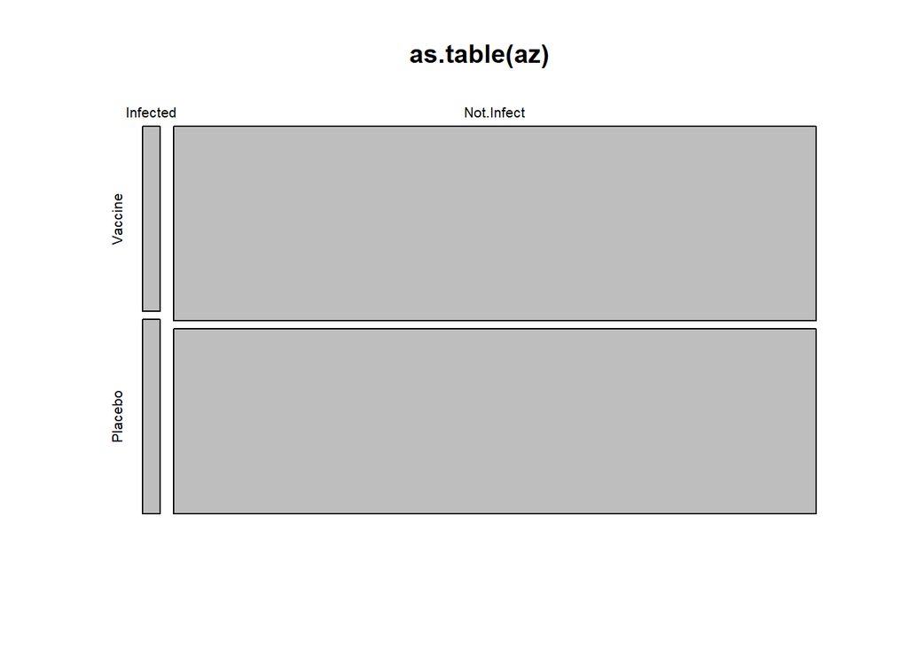

```r
plot(as.table(az))
```

The key question in studies like this is how much of an effect the treatment has on the risk for infection. From the mosaic plot above we get a suspicion that the protective effect of the AstraZeneca-Oxford vaccine against B.1.351 infection is not large since the infected areas for Vaccine and Placebo look quite similar. We can start by calculating the probabilities of infection in the 2 treatment groups. Even if this may sound a bit morbid, we will consider “Infected” to mean success in this trial.

```r
(p.inf <- az["Infected", ] / colSums(az))
```

```
##    Vaccine    Placebo
## 0.02540107 0.02801120
```

Notice how we use the rownames to extract different rows of the table. We see that there actually seems to be slightly higher probability of success (i.e., getting infected) from the placebo. We can also calculate the odds of success for the two treatments as

```r
(odds.inf <- p.inf / (1 - p.inf))
```

```
##    Vaccine    Placebo
## 0.02606310 0.02881844
```

We notice in passing that the probabilities for success and non-success in the same treatment have the same denominator (`colSums(az`)) such that we can also calculate the odds directly from the counts (`az["Infected", ] / ac["Not.Infect", ]`); check it out and take a moment to think about why this has to be so. Finally, we can calculate the odds ratio of the treatments, which represents the relative change in odds between the treatment and the placebo:

```r
(odds.ratio <- odds.inf["Vaccine"] / odds.inf["Placebo"])
```

```
##   Vaccine
## 0.9043896
```

The ratio is obviously close to 1 (i.e., identical odds in the two treatments), but we would also have liked to quantify the uncertainty in this estimate before we conclude anything about the efficacy of the AstraZeneca-Oxford vaccine against the new variant. We can approach this in many ways, but here we will show how to get this information by fitting the contingency table to a binomial generalized linear model (`glm`).

Binomial `glm`s are different from other linear model we have encountered in the sense that the response variable need to consist of two columns (the exception is *binary* binomial models where each observation is just a binary TRUE/FALSE variable); one for number of successes and one for number of failures. We usually do this by using the `cbind` function to make a two-column vector as the response variable. In our case the data are already in a 2 by 2 table, but we need to transpose this table to have one column for the number of successes (infected) and the number of failures (not infected). The predictor variable will just be a factor representing the treatments, which we extract from the column names of the contingency table. We also notice that `Placebo` will become the reference level by the default alphabetical ordering of factor levels.

```r
(outcome <- cbind(Infected=az["Infected", ], Not.Infect=az["Not.Infect", ]))
```

```
##         Infected Not.Infect
## Vaccine       19        729
## Placebo       20        694
```

```r
(treatment <- factor(colnames(az)))
```

```
## [1] Vaccine Placebo
## Levels: Placebo Vaccine
```

We then fit `y` to `x` using a `glm` of the binomial family with logit link (which is the default but which we specify here for clarity)

```r
summary(m <- glm(outcome ~ treatment, family=binomial(link="logit")))
```

```
##
## Call:
## glm(formula = outcome ~ treatment, family = binomial(link = "logit"))
##
## Deviance Residuals:
## [1]  0  0
##
## Coefficients:
##                  Estimate Std. Error z value Pr(>|z|)
## (Intercept)       -3.5467     0.2268 -15.638   <2e-16 ***
## treatmentVaccine  -0.1005     0.3247  -0.309    0.757
## ---
## Signif. codes:  0 '***' 0.001 '**' 0.01 '*' 0.05 '.' 0.1 ' ' 1
##
## (Dispersion parameter for binomial family taken to be 1)
##
##     Null deviance:  9.5819e-02  on 1  degrees of freedom
## Residual deviance: -1.6875e-14  on 0  degrees of freedom
## AIC: 13.579
##
## Number of Fisher Scoring iterations: 3
```

By the default factor level ordering, the `(Intercept)` parameter is an estimate of log(odds) for infection in the placebo treatment: $\alpha =\log(odds)$ = `coef(m)[1]` = -3.547, which is equivalent to a probability $p = \exp(\alpha) /(1 + \exp(\alpha))$ = `exp(coef(m)[1]) / (1 + exp(coef(m)[1]))` = 0.028, which is identical to the probability that we computed above, directly from the contingency table. The parameter `xVaccine` is the difference between the $\log(odds)$ for the placebo and the vaccine treatment. As we remember, a difference between logarithms is the same as the logarithm of the ratio of the arguments ($\log(A/B) = \log(A) - \log(B)$), such that this contrast can be interpreted as the logarithm of the *odds ratio* between the vaccine and placebo treatments: $\beta =\log(odds ratio)$ = `coef(m)[2]` = -0.1005. Anti-log of this coefficient $\exp(\beta)$ = `exp(coef(m)[2])` = 0.904 thus represents the odds ratio between treatments, which is simply the odds ratio we calculate directly from the contingency table (0.904).

The advantage of doing this estimation by a `glm` is that we can also get confidence intervals for the estimates;

```r
exp(confint(m)[2, ])
```

```
##     2.5 %    97.5 %
## 0.4754031 1.7147719
```

In other words, we have 95% confidence that the odds of infection could be from 52% lower to 71% higher in the vaccine treatment relative to the placebo. Hence, we find little support for claiming that the AstraZeneca-Oxford vaccine substantially prevents infection by B.1.351 variant of the SARS-CoV-2 virus – the vaccine may reduce the odds of infection by about 50%, but it is unlikely that the vaccine has a much stronger effect than that. If we get more data, the confidence interval will become narrower, but it will not necessarily be centered around 1 (equal odds).

### Other link functions

The logit (log-odds) link function we have used so far

$$\log \left( \frac{p_i}{1-p_i} \right) = \mathbf{x}_i \mathbf{\beta}$$

is the default link function when specifying `family = binomial` in the `glm` function, and is probably also the most used link function for binomial models. This is a choice based on tradition and convenience and not biological theory (it actually originates from gambling theory). When the probabilities we estimate represent something that does *not* accumulate over time, but rather something similar to an instantaneous coin flip, using the logit link, and hence interpreting contrasts as odds-ratios, is a good choice. However, when we model probabilities for something occurring or not occurring in a defined period of time (or in a sample of a defined volume), it makes much more sense to us the ‘loglog link’ (when estimating the probability of something *not* occurring in an interval/volume),

$$\log \left( -\log \left( p_i \right) \right) = \mathbf{x}_i
\mathbf{\beta}$$

or the ‘complementary loglog link’ (when estimating the probability of something occurring at least once in an interval/volume)

$$\log \left( -\log \left( 1-p_i \right) \right) = \mathbf{x}_i
\mathbf{\beta}$$

The latter is often called the ‘cloglog’ link.

For example, if we want to estimate the probability that individuals survive (not die) an interval of a fixed length (the longer the interval, the lower the probability of survival), it would make sense to use the ‘loglog’ link. If we instead model the probability of mortality, we would use the ‘cloglog’ link. With these link functions, contrasts in the linear predictors become the log of hazard ratios – i.e., the antilog of a contrast is the ratio of two hazard rates, where a hazard rate is the “instantaneous failure rate” (defined more exactly below). We don’t prioritize time to work with these link-functions in this course, but this is something you should read up on if you later need to model survival or mortality probabilities (or anything occurring or not occurring within time intervals). We provide some more details for those interested in the box below.

**ADVANCED (may be skipped):**

### *Modelling $p$ with the (complementary) log-log link

We will here walk trough a couple of examples using the complementary log-log link in binomial models. First we will look into estimation of survival probabilities and mortality rates. Thereafter, we will look into an ingenious method for estimating the density of bacteria in water samples.

#### Hazard rates and survival probabilities

The time of death (or any type of “failure”) of an individual (or any study unit) may follow a probability distribution $f(t)$. The hazard rate, or the “instantaneous failure rate”, is then

$$\lambda(t) = \frac{f(t)}{1-F(t)}$$
where $F(t)$ is the cumulative distribution, $F(t) = \int_{x=-\infty}^{t}{f(x)}dx$.

You can think of this formula for the hazard rate as meaning “the probability of dying during a short time interval after time $t$ given that the individual is alive at time $t$ (note that the probability of being alive (not yet dead) at time $t$ is $1-F(t)$).

When the hazard rate is constant, $\lambda(t) = \lambda$, the probability of surviving from time $0$ to time $t$ is

$$S(t) = \exp(-\lambda t)$$

If the hazard rate is a function of time, $\lambda(t)$, we have

$$S(t) = \exp \left( -\int_0^t \lambda(t) dt \right)$$

You can see the relationship between this and the Poisson distribution by imagining an immortal individual exposed to mortality events at an intensity of $\lambda$. The expected number of such events experienced during an interval of length $t$ is then $\bar\lambda t$, where $\bar\lambda$ is the time-averaged hazard rate in the interval, and the probability of experiencing zero events (i.e. surviving) in the interval is $\exp(-\bar\lambda t)$ (recall the the Poisson probability mass function, $P(X=x) = \lambda^x \exp(-\lambda)/x!$, and insert $x=0$).

The hazard rate $h$ is a ratio-scaled metric (see the tutorial of Week 5) that is natural to model with a log-linear model (i.e., modelling multiplicative effects on $h$). Hence, inserting $\bar\lambda = \exp(\eta)$, and considering survival probability over one time unit, we get the inverse of the log-log link,

$$S = \exp(-\exp(\eta))$$
which is equivalent to $\log(-\log(S)) = \eta$. If we instead model the probability of mortality, $P=1-S$, we get the complementary log-log link, $\log(-\log(1-P)) = \eta$.

When modelling mortality, or any type of events that occur to study units over time, it is essential to account for individuals that are removed or disappear from the sample as the individuals age (removed individuals are said to be “censored”). Typically, individuals that live for a long time have a higher chance of becoming censored simply because they are exposed to censoring for a longer time (note also that individuals that are alive at the end of the study are also censored). Hence, if we ignore censoring, we will get biased estimates of survival and mortality.

When studying other events occurring to individuals over time, such as maturing, getting infected by a pathogen or developing a medical condition such as cancer or diabetes, mortality is a natural cause of censoring. It is therefore not possible to study the hazard rates for such events (or their corresponding event time distribution ($f(t)$) or survival function ($S(t)$)) without accounting for mortality in one way or another.

A further complication is that mortality hazard rates are typically heterogeneous in a population; I.e., some individuals have a lower or higher hazard rate than other individuals in the population due to e.g. genetic differences or the amount of resources they possess. When this is the case, a sample of individuals will be dominated more and more by the “high quality” individuals over time (i.e., those with low mortality hazard rates) as the “low quality” individuals tend to die early and disappear from the remaining sample. Hence, it is not uncommon to see that the mean (or overall) mortality hazard rate in the population *decrease* at higher age even when the hazard rate for every individual *increase* as they age (this is often referred to as a “frailty” effect – frail individuals disappear earlier from the sample/population).

Unfortunately, we don’t have time to go any deeper into these issues in this course, but these are important issues that you need to understand if you are going to work with survival data, or data on events occurring to individuals over time, in the future.

#### Most Probable Number (MPN)

The Most Probable Number (MPN) method has been used in microbiology since at least the 1930ies to quantify the number of organisms in a sample. The method is particularly useful for quantifying organisms which cannot be identified by morphology but rather by their ability to grow in specific media, which was the case for much of bacterial systematics before emergence of current DNA-based classifications. The MPN method has, for example, remained a standard method for estimating the number of fecal coliform bacteria in water samples. Fecal coliforms, which live exclusively in the guts of endothermic animals, are considered good indicators of fresh sewage pollution, and thus an important hygienic quality parameter for assessing the suitability of a water source for consumption and recreation.

The basic principle for the MPN method is to make a dilution series of the original sample and record whether growth can be detected or not at the different dilution levels. Dilution levels are typically chosen as a geometric series on powers of 2 or 10. One may for example add 1, 1/2, 1/4, 1/8, 1/16, etc millilitres (mL) of the sample to tubes containing a volume of sterile growth medium that is selective for fecal coliforms. The tubes are then incubated at optimal growth conditions (37º C for fecal coliforms) and growth recorded as visible turbidity in a tube. The different dilution levels are typically replicated several times to increase the precision of the method.

The statistical basis for the MPN method was worked out by R. A. Fisher himself and used by him as an example of maximum likelihood estimation. We will here use simulation to illustrate Fisher’s analysis of the MPN method, and show how the MPN estimate can be found by a particular kind of generalized linear model.

Assume that we have a sample that contains an average of $\lambda$ bacteria per mL of liquid. Thus the average number of bacteria in 1/2 mL, 1/4 mL, 1/8 mL, … will be $\lambda/2$, $\lambda/4$ $\lambda/8$, … and generally $\lambda 2^{-i}$ in $2^{-i}$ mL of liquid. If the bacteria are randomly distributed in the original sample, then the number of bacteria ($N$) in a population of 1 mL subsamples from the same source can be described by a Poisson distribution with intensity parameter $\lambda$ ($N \sim \text{Poisson}(\lambda)$), while the distribution of bacterial numbers in a population of $2^{-i}$ mL subsamples will be $\sim \text{Poisson}(\lambda 2^{-i})$.

A certain subsample will only give growth if it contained at least 1 bacterial cell, which means that $P(\text{growth}) = P(N>0)$. Since the domain of $N$ is the natural numbers (0, 1, 2, … then ) then the law of complementary probability tells us that $P(N>0) = 1 - P(N=0)$. Since Poisson probability for $N=0$ is simply $exp(-\lambda)$ (check this out yourself!), the probability of growth in dilution $i$ becomes $p_i = 1 - \exp(-\lambda 2^{-i})$. By rearranging the terms and log-transforming both sides twice (check out yourself!) we can show that this equation can be rewritten as

$$\log(-\log(1 - p_i)) = \log(\lambda) -
\log(2) i$$
In other words, the complementary log-log of the probability of growth should be a linear function of the dilution level $i$ with slope $-\log(2)$ and intercept equal to the logarithm of the initial bacterial abundance ($\lambda$), which is what we sought to estimate.

We can simulate the MPN method by using the `rpois()` function for generating random, Poisson-distributed numbers. We assume that the true number of bacteria, $\lambda$ = 2 / mL, and that we use 7 dilution levels (1/1, 1/2, 1/4 … 1/64) and 8 replicates at each dilution level.

```r
Lambda <- 2
i <- 0:6
i.k <- rep(i, each = 8)
lambda.k <- Lambda * (2^(-i.k))

set.seed(123456) # Just so we get the same numbers every time...
N.k <- rpois(length(i.k), lambda = lambda.k)
```

```r
growth <- tapply(N.k>0, i.k, sum) #No. 'growth' in each dilution group
no.growth <- (8 - growth)         #No. 'no growth' in each dilution group

rbind(growth, no.growth) # Looking at the generated data
```

```
##           0 1 2 3 4 5 6
## growth    7 7 2 4 1 0 0
## no.growth 1 1 6 4 7 8 8
```

This means that we can see the MPN method as a set of binomial experiments where each group of 8 replicates has the same probability of growth, and where the complementary log-log of each growth probability is linearly related to the dilution level (i). In other words, we should be able to describe the MPN experiment by a generalized linear model with the default link function of the binomial family (the logit link) replaced by a complementary log-log link.

```r
summary(m <- glm(cbind(growth, no.growth) ~ i, family = binomial(link = "cloglog")))
```

```
##
## Call:
## glm(formula = cbind(growth, no.growth) ~ i, family = binomial(link = "cloglog"))
##
## Deviance Residuals:
##        0         1         2         3         4         5         6
## -0.57987   1.03454  -1.22332   1.48271  -0.05283  -1.03764  -0.71757
##
## Coefficients:
##             Estimate Std. Error z value Pr(>|z|)
## (Intercept)   0.9897     0.3666   2.700  0.00693 **
## i            -0.7377     0.1712  -4.308 1.65e-05 ***
## ---
## Signif. codes:  0 '***' 0.001 '**' 0.01 '*' 0.05 '.' 0.1 ' ' 1
##
## (Dispersion parameter for binomial family taken to be 1)
##
##     Null deviance: 35.9224  on 6  degrees of freedom
## Residual deviance:  6.6958  on 5  degrees of freedom
## AIC: 21.23
##
## Number of Fisher Scoring iterations: 5
```

The `(Intercept)` is an estimate for $\log(\lambda)$, such that its anti-log becomes an estimate of to original bacterial abundance `exp(coef(m)[1]` = 2.69 which in this particular simulation is slightly above the true value (2). Slope is fairly close to the theoretical value $-\log(2)$ = -0.693.

We can also compute 95% confidence intervals for the estimates and back-transform:

```r
exp(confint(m))
```

```
##                 2.5 %    97.5 %
## (Intercept) 1.3270911 5.3058926
## i           0.3335562 0.6445682
```

From which we see that both confidence intervals enclose the true values: 2 for the intercept and $\exp(-\log(2))$ = 1/2 for the slope.

## Exercise: Side-effects in AstraZeneca vaccinations

There has recently been raised concerns about possible serious side-effects of the AstraZeneca vaccine against covid-19 disease. Occurrence of sometimes fatal blood clots in otherwise healthy individuals injected with the AstraZeneca vaccine have lead many countries to pause the use of it, especially for younger individuals. According to an article in Norwegian newspaper [Aftenposten](https://www.aftenposten.no/norge/i/yRxgga/legemiddelverket-lite-realistisk-at-vi-kan-plukke-ut-hvem-som-ikke-boe) on March 23rd., 2021, 30 cases of serious blood clot complications have been reported among the 20 million who have been injected with this vaccine worldwide, while this condition has developed in 6 cases among the 130 000 who have received this vaccine in Norway.

Use the 4 numbers given in the article to compute the side-effect probabilities in Norway and worldwide, and the odds ratio for developing side-effects between the two groups. Estimate the same odds ratio with a generalized linear model of the binomial family, and use this model to construct a 95% confidence interval for the odds ratio. Is this result in support of the odds being different between Norway and the world in general? If so, what could be the cause? Discuss possible explanations including:

- Different age groups vaccinated (mainly health-care workers in Norway)?
- Differences between populations (genetics, nutrition, life style, etc.)?
- A bad vaccine batch shipped to Norway?
- Differences in detection / reporting of blood clots?

## Assignment: Diabetes in the Pima Indians

The Akimel O’odham or Pima are a group of Native Americans living in an area consisting of what is now central and southern Arizona (USA) and Sonora (Mexico). The name “Pima” apparently means “I don’t know”, a phrase used repeatedly in their initial meeting with Europeans.

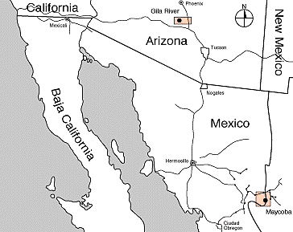

As with other Native Americans, the Pima people have a higher prevalence of type 2 diabetes than is observed in Caucasian populations. While they do not have a greater risk than other tribes, the Pima people have been the subject of intensive study of diabetes, in part because they form a homogeneous group. The general increased diabetes prevalence among Native Americans has been hypothesized as the result of the interaction of genetic predisposition (the thrifty phenotype or thrifty genotype as suggested by anthropologist Robert Ferrell in 1984) and a sudden shift in diet from traditional agricultural goods towards processed foods in the past century.

The National Institute of Diabetes and Digestive and Kidney Diseases conducted a study on 768 adult female Pima Indians living near Phoenix. The following variables were recorded:

- `npreg`: Number of times pregnant
- `glu`: Oral glucose tolerance test
- `bp`: Diastolic blood pressure (mm Hg)
- `skin`: Triceps skin fold thickness (mm)
- `bmi`: Body mass index (kg / m<sup>2</sup>)
- `ped`: Diabetes pedigree function
- `age`: Age (years)
- `diabetes`: Diabetes diagnosed (“No” or “Yes”)

The original data set contained numerous missing values which apparently were encoded as zeros, such that there were a number of cases with e.g. blood pressure = 0! The file “Pima-indian-diabetes.csv” contains only the 332 complete cases in the original data set (i.e., no missing values). The Diabetes Pedigree Function (`ped`) was developed by [Smith et al. (1988)](https://www.ncbi.nlm.nih.gov/pmc/articles/PMC2245318/pdf/procascamc00018-0276.pdf) to provide a synthesis of the diabetes history in relatives and the genetic relationship of those relatives to the subject. It uses information from parents, grandparents, siblings, aunts and uncles, and first cousins and provides a measure of the expected genetic influence of affected and unaffected relatives on the subject’s eventual diabetes risk. The oral glucose tolerance test is a standard test for diabetes involving measuring plasma glucose 2 hours after oral intake of an amount of glucose. The triceps skin fold test is a standard measure of subcutaneous fat, and as such, an indicator of obesity similar to the body mass index. The other variables are largely self-explanatory. The last variable is a binary indicator for whether the person has been diagnosed with diabetes or not.

A. Read the file “Pima-indian-diabetes.csv” into R. For the rest of the exercise it is more convenient if we change the variable `diabetes` from factor to a logical variable which is `TRUE` for factor level “Yes”, so do this conversion (hint: `diabetes == "Yes"` gives a logical variable; notice the double equals sign). Use `head()` and `summary()` to assure yourself the file has been read properly.

B. Our task is to predict `diabetes` from other variables. It is therefore a good idea to first look at relationships between the predictor variables by making scatterplot and correlation matrices (hint: `plot()` on a `data.frame` object is identical to using the `pairs()` function). *Are there any predictor variables that are closely related? If so, can you think of explanations for this?* (hint: look at for example `bmi` vs. `skin`, or `age` vs. `npreg`). *Which considerations should we make when using any of these pairs in a model?*

C. Use boxplots to investigate the distributions of at least 4 predictor variables grouped by diabetes status. You can use the `boxplot()` function with a formula like `glu ~ factor(diabetes)`. Notice that this works better if you cast the now logical variable `diabetes` into a factor again. Using the argument `horizontal=TRUE` in the `boxplot()` call makes the figure easier to read.

D. Pick one of the predictor variables you investigated in part C and make a univariate binomial `glm` with logit link where you use this variable to predict diabetes status. Notice that since our response variable is binary, we do not need to use `cbind()` to make a 2-column vector for the response variable. *Explain how you interpret the intercept and slope estimates in this model.* *Make a 95% confidence interval for the relative change in odds per unit change in the predictor variable* (depending on the variable you choose, it may increase readability to compute the relative change per 10 or 100 units).